# HDL cholesterol in US adults

Dataset 10: NHANES adults (2009-10 and 2011-12 extract)

RSR feasibility analysis

2026-08-03

# Introduction

The National Health and Nutrition Examination Survey (NHANES) is a continuous cross-sectional survey of the civilian non-institutionalised US population, pairing a household interview with a standardised examination and venous blood draw. This teaching extract holds 488 adults aged 21 to 80 from the 2009-10 and 2011-12 cycles. HDL cholesterol is the “good” lipid fraction: low HDL is a component of the metabolic syndrome definition and an independent marker of cardiovascular risk, and unlike total cholesterol it is only weakly affected by statin therapy, so its determinants can be studied with less treatment contamination.

**Aim.** Among these US adults, we examined which of age, sex, BMI, recreational physical activity, smoking history, alcohol frequency and diagnosed diabetes are independently associated with HDL cholesterol, mutually adjusting for the others.

This is a *Purpose 3* analysis: several predictors are of interest and the question is which remain associated with the outcome after mutual adjustment.

# Methods

**Data source.** NHANES 2009-10 and 2011-12, a complex multistage probability sample of the US civilian non-institutionalised population. This extract contains 488 adults with 31 variables. Lipids were measured on a venous sample taken in the mobile examination centre.

**Variables.** The outcome is `hdl_cholesterol`, HDL cholesterol in mmol/L, treated as continuous. Predictors are age (years), sex (reference female), BMI (kg/m2), recreational moderate or vigorous physical activity (reference no), ever having smoked 100 cigarettes (reference no), number of drinking days in the past year and doctor-diagnosed diabetes (reference no). These seven were chosen because each has an established biological pathway to HDL: adiposity and insulin resistance lower it, aerobic activity and moderate alcohol raise it, and smoking lowers it.

`total_cholesterol` is deliberately excluded: HDL is by laboratory definition a component of total cholesterol, so the two are related partly by construction and a coefficient for total cholesterol here has no substantive meaning. `weight_kg` and `height_cm` are excluded because `bmi` is exactly `weight_kg / (height_cm/100)^2` in this file.

**Statistical analysis.** `lm()`, justified because the outcome is continuous. We fitted a univariable model for each predictor first, then a single multivariable model containing all of them. Predictors were chosen in advance on subject-matter grounds, not by significance. Significance threshold 0.05; estimates are reported with 95% confidence intervals. Assumptions were checked with `performance::check_model()`, and because non-constant variance was flagged we additionally report HC3 heteroscedasticity-consistent standard errors. Models are **unweighted**: the NHANES survey weights, strata and primary sampling units are not carried in this extract, so no result here is a nationally representative estimate. Analysis used R version 4.6.0 (2026-04-24) with tidyverse, gtsummary and performance.

**Missing data.** Complete-case analysis: 383 of 488 rows were analysed (105 dropped). Most of the loss comes from `alcohol_days_year` (88 missing, 18%) plus `hdl_cholesterol` itself (27 missing). Only 172 of 488 rows are complete on *every* variable in the file, so listwise deletion is a live threat and the complete-case N is reported for every model.

# Results

## Sample characteristics

**Table 1. Sample characteristics.**

| **Characteristic** | **N** | **N = 383**<sup>1</sup> |
| --- | --- | --- |
| HDL cholesterol (mmol/L) | 383 | 1.34 (1.11, 1.63) |
| Age (years) | 383 | 50 (37, 63) |
| Sex | 383 |  |
| Female |  | 191 (50%) |
| Male |  | 192 (50%) |
| BMI (kg/m2) | 383 | 28 (25, 33) |
| Recreationally physically active | 383 | 200 (52%) |
| Ever smoked 100+ cigarettes | 383 | 182 (48%) |
| Drinking days in past year | 383 | 24 (3, 104) |
| Diagnosed diabetes | 383 | 44 (11%) |

<sup>1</sup> Median (Q1, Q3); n (%)

Median HDL is about 1.3 mmol/L, with a mild right skew. Reported drinking days per year are heavily right-skewed - a large group reports very few days and a minority reports near-daily drinking - and the median BMI is in the overweight range.

## Exploratory figure

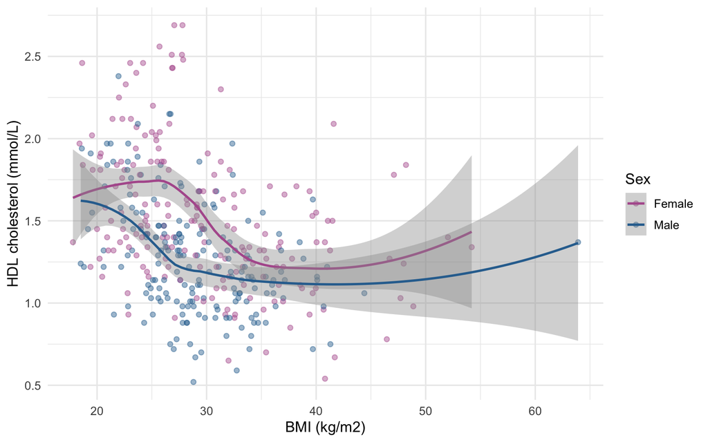

Figure 1. HDL cholesterol against BMI, by sex, with LOESS smoothers.

## Univariable models

| **Characteristic** | **N** | **Beta** | **95% CI** | **p-value** |
| --- | --- | --- | --- | --- |
| Age (years) | 383 | 0.00 | 0.00, 0.01 | 0.014 |
| Sex | 383 |  |  |  |
| Female |  | — | — |  |
| Male |  | -0.25 | -0.33, -0.17 | <0.001 |
| BMI (kg/m2) | 383 | -0.02 | -0.03, -0.02 | <0.001 |
| Recreationally physically active | 383 |  |  |  |
| No |  | — | — |  |
| Yes |  | 0.06 | -0.02, 0.14 | 0.2 |
| Ever smoked 100+ cigarettes | 383 |  |  |  |
| No |  | — | — |  |
| Yes |  | -0.05 | -0.13, 0.03 | 0.2 |
| Drinking days in past year | 383 | 0.00 | 0.00, 0.00 | <0.001 |
| Diagnosed diabetes | 383 |  |  |  |
| No |  | — | — |  |
| Yes |  | -0.08 | -0.21, 0.05 | 0.2 |

Abbreviation: CI = Confidence Interval

Three predictors show strong crude associations. Men average -0.250 mmol/L (95% CI -0.327 to -0.172) lower HDL than women (p <0.001), which is the largest single difference in the dataset. Each additional kg/m2 of BMI is associated with -0.022 mmol/L (95% CI -0.027 to -0.016) lower HDL (p <0.001), so a 10-unit BMI difference corresponds to about 0.22 mmol/L. Each additional drinking day per year is associated with 0.0010 mmol/L (95% CI 0.0007 to 0.0014) higher HDL (p <0.001); scaled up, 100 extra drinking days a year corresponds to about 0.10 mmol/L. Age is weakly positive (0.003 mmol/L (95% CI 0.001 to 0.005), p = 0.014). Physical activity, smoking and diabetes show no clear crude association.

## Multivariable model

| **Characteristic** | **Beta** | **95% CI** | **p-value** |
| --- | --- | --- | --- |
| Age (years) | 0.00 | 0.00, 0.00 | 0.012 |
| Sex |  |  |  |
| Female | — | — |  |
| Male | -0.29 | -0.36, -0.23 | <0.001 |
| BMI (kg/m2) | -0.02 | -0.02, -0.01 | <0.001 |
| Recreationally physically active |  |  |  |
| No | — | — |  |
| Yes | 0.02 | -0.05, 0.09 | 0.5 |
| Ever smoked 100+ cigarettes |  |  |  |
| No | — | — |  |
| Yes | -0.04 | -0.11, 0.03 | 0.2 |
| Drinking days in past year | 0.00 | 0.00, 0.00 | <0.001 |
| Diagnosed diabetes |  |  |  |
| No | — | — |  |
| Yes | -0.02 | -0.14, 0.09 | 0.7 |

Abbreviation: CI = Confidence Interval

**Model fit: multivariable linear model for HDL cholesterol**

| Statistic | Value |
| --- | --- |
| Complete-case N | 383 |
| Parameters (excl. intercept) | 7 |
| R-squared | 0.313 |
| Adjusted R-squared | 0.301 |
| Residual SE (mmol/L) | 0.339 |

The model explains 31.3% of the variance in HDL (adjusted R-squared 0.301), by far the best fit of the four continuous outcomes in this dataset. Among participants of the same age, BMI, activity, smoking, drinking and diabetes status, men average -0.295 mmol/L (95% CI -0.365 to -0.225) lower HDL than women (p <0.001). Among participants alike on everything else, each additional kg/m2 of BMI is associated with -0.019 mmol/L (95% CI -0.025 to -0.014) lower HDL (p <0.001), each extra drinking day per year with 0.0010 mmol/L (95% CI 0.0007 to 0.0013) higher HDL (p <0.001), and each year of age with 0.003 mmol/L (95% CI 0.001 to 0.005) higher HDL (p = 0.012). Physical activity (0.024 mmol/L (95% CI -0.046 to 0.095), p = 0.500), smoking (-0.041 mmol/L (95% CI -0.110 to 0.028), p = 0.240) and diabetes (-0.024 mmol/L (95% CI -0.138 to 0.090), p = 0.683) are not independently associated. These are associations among the participants observed, not effects of intervening.

## Unadjusted versus adjusted

**Table 2. Unadjusted and adjusted estimates.**

| **Characteristic** | **Unadjusted** **N** | **Unadjusted** **Beta** | **Unadjusted** **95% CI** | **Unadjusted** **p-value** | **Adjusted** **Beta** | **Adjusted** **95% CI** | **Adjusted** **p-value** |
| --- | --- | --- | --- | --- | --- | --- | --- |
| Age (years) | 383 | 0.00 | 0.00, 0.01 | 0.014 | 0.00 | 0.00, 0.00 | 0.012 |
| Sex | 383 |  |  |  |  |  |  |
| Female |  | — | — |  | — | — |  |
| Male |  | -0.25 | -0.33, -0.17 | <0.001 | -0.29 | -0.36, -0.23 | <0.001 |
| BMI (kg/m2) | 383 | -0.02 | -0.03, -0.02 | <0.001 | -0.02 | -0.02, -0.01 | <0.001 |
| Recreationally physically active | 383 |  |  |  |  |  |  |
| No |  | — | — |  | — | — |  |
| Yes |  | 0.06 | -0.02, 0.14 | 0.2 | 0.02 | -0.05, 0.09 | 0.5 |
| Ever smoked 100+ cigarettes | 383 |  |  |  |  |  |  |
| No |  | — | — |  | — | — |  |
| Yes |  | -0.05 | -0.13, 0.03 | 0.2 | -0.04 | -0.11, 0.03 | 0.2 |
| Drinking days in past year | 383 | 0.00 | 0.00, 0.00 | <0.001 | 0.00 | 0.00, 0.00 | <0.001 |
| Diagnosed diabetes | 383 |  |  |  |  |  |  |
| No |  | — | — |  | — | — |  |
| Yes |  | -0.08 | -0.21, 0.05 | 0.2 | -0.02 | -0.14, 0.09 | 0.7 |

Abbreviation: CI = Confidence Interval

Sex moves *away* from the null, from -0.250 mmol/L (95% CI -0.327 to -0.172) crude to -0.295 mmol/L (95% CI -0.365 to -0.225) adjusted - an 18% increase in magnitude. This is masking rather than confounding: men drink on more days, and drinking raises HDL, so the crude male deficit was partly offset by the male drinking advantage; removing it makes the sex gap larger. Diabetes moves substantially toward the null, from -0.081 mmol/L (95% CI -0.209 to 0.046) to -0.024 mmol/L (95% CI -0.138 to 0.090), a two-thirds attenuation, because the crude diabetes deficit was mostly the high BMI of participants with diabetes. Physical activity also attenuates toward the null (0.057 mmol/L (95% CI -0.025 to 0.138) to 0.024 mmol/L (95% CI -0.046 to 0.095)) for the same reason - active people are leaner, and once BMI is held constant the residual activity association nearly disappears, which is arguably over-adjustment since lower BMI is one of the mechanisms by which exercise raises HDL. Two predictors barely move: BMI (-0.022 mmol/L (95% CI -0.027 to -0.016) to -0.019 mmol/L (95% CI -0.025 to -0.014)) and alcohol (0.0010 mmol/L (95% CI 0.0007 to 0.0014) to 0.0010 mmol/L (95% CI 0.0007 to 0.0013)), both remaining highly significant. No predictor changes significance status in either direction.

## Diagnostics

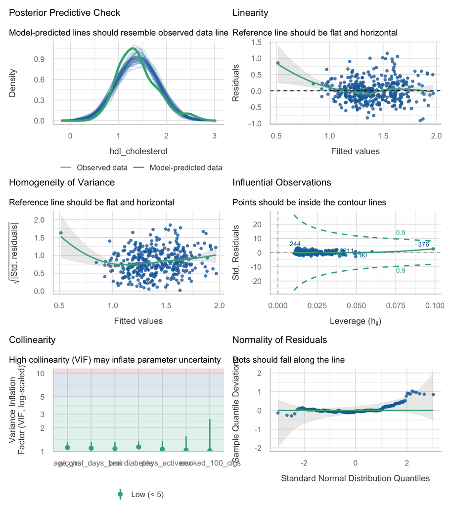

**Table 3. HC3 heteroscedasticity-consistent standard errors.**

| Term | Estimate | SE (OLS) | SE (HC3) | 95% CI (HC3) | p (HC3) |
| --- | --- | --- | --- | --- | --- |
| age_yrs | 0.0028 | 0.0011 | 0.0012 | 0.000 to 0.005 | 0.019 |
| sexMale | -0.2950 | 0.0354 | 0.0359 | -0.366 to -0.224 | 0.000 |
| bmi | -0.0194 | 0.0028 | 0.0033 | -0.026 to -0.013 | 0.000 |
| phys_activeYes | 0.0242 | 0.0359 | 0.0372 | -0.049 to 0.097 | 0.516 |
| smoked_100_cigsYes | -0.0414 | 0.0352 | 0.0351 | -0.110 to 0.028 | 0.240 |
| alcohol_days_year | 0.0010 | 0.0002 | 0.0002 | 0.001 to 0.001 | 0.000 |
| diabetesYes | -0.0238 | 0.0581 | 0.0583 | -0.138 to 0.091 | 0.684 |

Because variance is non-constant, Table 3 reports HC3 robust standard errors. For BMI the HC3 SE is 0.0033 against an OLS SE of 0.0028, and for alcohol 0.0002 against 0.0002. The differences are small and every predictor keeps its significance status, so the conclusions are robust to the variance assumption. A log transformation of HDL would remove both the skew and most of the heteroscedasticity if a student wanted a cleaner model.

# Discussion

In this NHANES extract, sex, BMI, alcohol frequency and age are each independently associated with HDL cholesterol, and together they explain 31.3% of its variance. The sex difference is large - men average about 0.29 mmol/L lower than otherwise-similar women - and adiposity is the main modifiable correlate, with roughly 0.19 mmol/L lower HDL per 10 kg/m2 of BMI. The positive alcohol association is consistent with the well-documented HDL-raising effect of regular moderate drinking, but it is not a reason to recommend drinking. Practically, the results reinforce that HDL should be interpreted against sex-specific thresholds, as clinical guidelines already do.

**Limitations.** The models are unweighted, and the NHANES sampling weights, strata and PSUs are not in this extract, so the sample **must not be described as nationally representative**. The design is cross-sectional, so no temporal ordering is established. `alcohol_days_year` counts *days*, not volume, so it cannot separate a daily light drinker from a daily heavy drinker, and heavy drinking has a different lipid profile from moderate drinking; it is also self-reported and under-reporting is systematic. Physical activity is a bare yes/no with no intensity or duration. Adjusting for BMI probably removes part of the genuine effect of activity on HDL, since weight is on the causal path. Complete-case analysis dropped 105 of 488 rows (22%), most of them for missing alcohol data, and drinkers who decline to report are unlikely to be a random subset. Residual variance is non-constant and residuals are right-skewed; HC3 SEs address inference but the model still cannot predict the high-HDL tail. All estimates are associations, not causal effects.

**Future work.** Refit on log(HDL) with the NHANES survey design, and use the full public files’ quantity-frequency drinking variables in place of drinking days.

# Feasibility notes

*NOT part of a student report.*

- **The best of the four linear outcomes, and probably the best outcome in the dataset.** R-squared 0.313, four clearly significant predictors with textbook biological interpretations, and a genuinely instructive unadjusted-versus-adjusted table containing both a masking effect (sex moves away from the null) and confounding (diabetes attenuates by two thirds).
- **Complete-case N 383 of 488** (22% lost), almost entirely because of `alcohol_days_year` (18% missing). Dropping alcohol raises N to about 445 but removes one of the two most interesting findings. This is a good, concrete illustration of the listwise-deletion trade-off.
- **Heteroscedasticity flagged (p = 0.008)** and non-normality of residuals. HC3 changes nothing substantive. Clean case for the “check, then report robust SEs” workflow.
- **Trap: `total_cholesterol` should not be a predictor** - HDL is a component of it by definition. Nothing will error, but the coefficient is partly an identity. Less obvious to students than the `bmi`/`obese` trap.
- **Trap: `weight_kg` / `height_cm` / `bmi`** - `bmi` is exactly `weight_kg/(height_cm/100)^2`; do not use all three.
- **Adjusting for BMI blocks part of the activity pathway.** Worth flagging as an over-adjustment discussion point rather than an error.
- **Unweighted survey analysis.** Must be stated.
- No separation, no collinearity (max VIF 1.14), no influential observations.